# Bases de datos policiales

Importación, limpieza, diagnóstico, uniones y primeras visualizaciones

Autor/a

Noam López Villanes

Fecha de publicación

13 de mayo de 2026

## 1 Objetivo de la sesión

En esta sesión trabajaremos con bases reales de información policial. El objetivo no es hacer todavía un análisis estadístico complejo, sino aprender una ruta ordenada para gestionar bases de datos:

1. Importar archivos CSV, Excel y SPSS.
2. Revisar estructura, nombres de variables y tipos de datos.
3. Detectar valores perdidos, duplicados y problemas de codificación.
4. Estandarizar variables clave, especialmente `ubigeo`.
5. Crear indicadores simples mediante agrupaciones.
6. Fusionar bases de datos con `left_join()`.
7. Elaborar primeras visualizaciones exploratorias.

## 2 Preparación

Si ejecutas este documento por partes, corre primero los chunks de **Instalar paquetes**, **Activar paquetes** y **Ubicar archivos**. Los tres están ocultos en el redenrizado final, pero esos bloques crean los paquetes, funciones y rutas que usan los demás chunks.

## 3 Importación

### 3.1 CSV: denuncias policiales

La base de denuncias policiales contiene registros agregados por período, lugar y modalidad.

```r
cargar_datos_originales()

denuncias <- read_csv(
  # read_csv() importa archivos separados por comas.
  file.path(ruta_csv, "denuncias.csv"),
  locale = locale(encoding = "UTF-8"),
  show_col_types = FALSE
)

# glimpse() muestra columnas, tipos y algunos valores de ejemplo.
glimpse(denuncias)
```

```
Rows: 355,947
Columns: 8
$ ANIO           <dbl> 2018, 2018, 2018, 2018, 2018, 2018, 2018, 2018, 2018, 2…
$ MES            <dbl> 1, 1, 1, 1, 1, 1, 1, 1, 1, 1, 1, 1, 1, 1, 1, 1, 1, 1, 1…
$ DPTO_HECHO_NEW <chr> "AMAZONAS", "AMAZONAS", "AMAZONAS", "AMAZONAS", "AMAZON…
$ PROV_HECHO     <chr> "BAGUA", "BAGUA", "BAGUA", "BAGUA", "BAGUA", "BAGUA", "…
$ DIST_HECHO     <chr> "ARAMANGO", "ARAMANGO", "BAGUA", "BAGUA", "BAGUA", "BAG…
$ UBIGEO_HECHO   <dbl> 10202, 10202, 10201, 10201, 10201, 10201, 10201, 10203,…
$ P_MODALIDADES  <chr> "Otros", "Violencia contra la mujer e integrantes", "Es…
$ cantidad       <dbl> 6, 1, 2, 25, 64, 7, 8, 4, 1, 1, 2, 1, 2, 1, 2, 4, 7, 14…
```

### 3.2 CSV: personal policial

```r
cargar_datos_originales()

personal <- read_csv(
  # La codificación UTF-8 permite leer correctamente tildes y eñes.
  file.path(ruta_csv, "personal.csv"),
  locale = locale(encoding = "UTF-8"),
  show_col_types = FALSE
)

glimpse(personal)
```

```
Rows: 19,187
Columns: 19
$ AÑO                    <dbl> 2026, 2026, 2026, 2026, 2026, 2026, 2026, 2026,…
$ MES                    <chr> "MARZO", "MARZO", "MARZO", "MARZO", "MARZO", "M…
$ DEPENDENCIAS_GENERALES <chr> "COMANDANCIA GENERAL", "COMANDANCIA GENERAL", "…
$ DEPENDENCIAS           <chr> "DIRECCION DE PRESTACIONES DE SALUD", "DIRECCIO…
$ UNIDADES               <chr> "DIRECCION DE SANIDAD POLICIAL", "DIRECCION DE …
$ DEPARTAMENTO           <chr> "TUMBES", "SAN MARTÍN", "LIMA METROPOLITANA", "…
$ PROVINCIA              <chr> "TUMBES", "SAN MARTIN", "LIMA", "LIMA", "TRUJIL…
$ DISTRITO               <chr> "TUMBES", "TARAPOTO", "RIMAC", "RIMAC", "TRUJIL…
$ SEXO                   <chr> "MASCULINO", "FEMENINO", "MASCULINO", "MASCULIN…
$ CATEGORIA_OFI_SUB      <chr> "OFICIAL", "SUB OFICIAL", "OFICIAL", "OFICIAL",…
$ CATEGORIA_ARM_SERV     <chr> "SERVICIOS", "ARMAS", "ARMAS", "ARMAS", "ARMAS"…
$ FUNCION                <chr> "ADM", "ADM", "ADM", "OPE", "OPE", "OPE", "ADM"…
$ APT.PSICOSOMATICA      <chr> "APTO COD. 0", "APTO COD. 0", "APTO COD. 0", "A…
$ ESTUDIOS_ADICIONALES   <chr> "SIN ESTUDIOS ADICIONALES", "SIN ESTUDIOS ADICI…
$ PROFESION              <chr> "SIN ESTUDIOS ADICIONALES", "SIN ESTUDIOS ADICI…
$ ORIGINARIOS            <chr> "CASTELLANO", "CASTELLANO", "CASTELLANO", "CAST…
$ EXTRANJERO             <chr> "MATERNO", "MATERNO", "INGLÉS", "MATERNO", "MAT…
$ CLASIFICACION          <chr> "OTRAS DEPENDENCIAS", "OTRAS DEPENDENCIAS", "OT…
$ CANTIDAD               <dbl> 2, 8, 1, 13, 176, 1, 1, 2, 1, 1, 1, 1, 2, 1, 3,…
```

### 3.3 CSV: parque automotor de la PNP

```r
cargar_datos_originales()

parque <- read_csv(
  # Importamos el parque automotor como tabla de trabajo.
  file.path(ruta_csv, "parque.csv"),
  locale = locale(encoding = "UTF-8"),
  show_col_types = FALSE
)

glimpse(parque)
```

```
Rows: 8,232
Columns: 13
$ AÑO                <dbl> 2025, 2025, 2025, 2025, 2025, 2025, 2025, 2025, 202…
$ MES                <chr> "JULIO", "JULIO", "JULIO", "JULIO", "JULIO", "JULIO…
$ UBIGEO             <dbl> 150101, 150109, 40126, 210201, 170103, 150115, 1101…
$ NOMBDEPTO          <chr> "LIMA METROPOLITANA", "LIMA METROPOLITANA", "AREQUI…
$ NOMBPROV           <chr> "LIMA", "LIMA", "AREQUIPA", "AZANGARO", "TAMBOPATA"…
$ NOMBDIST           <chr> "LIMA", "CIENEGUILLA", "YANAHUARA", "AZANGARO", "LA…
$ TIPO_VEHICULO      <chr> "CAMIONETA", "CAMIONETA", "MOTOCICLETA", "CAMIONETA…
$ TIPO_UNIDAD        <chr> "UNIDAD ADMINISTRATIVA", "UNIDAD ESPECIALIZADA", "U…
$ TIPO_VEHICULO_PRIO <chr> "CAMIONETA", "CAMIONETA", "MOTOCICLETA", "CAMIONETA…
$ TIPO_PROCEDENCIA   <chr> "COMPRA DIRECTA", "COMPRA DIRECTA", "COMPRA DIRECTA…
$ ESTADO             <chr> "INOPERATIVO IRRECUPERABLE", "INOPERATIVO IRRECUPER…
$ AÑOFABRICACION     <dbl> 2016, 2016, 2015, 2008, 2010, 2024, 2017, 2025, 201…
$ CANTIDAD           <dbl> 11, 1, 3, 1, 1, 2, 1, 1, 2, 1, 1, 1, 1, 1, 3, 1, 1,…
```

### 3.4 Excel: infraestructura de comisarías

```r
cargar_datos_originales()

infraestructura <- read_excel(
  # read_excel() permite indicar archivo y hoja.
  file.path(
    ruta_infraestructura,
    "infraestructura.xlsx"
  ),
  sheet = "BD"
)

glimpse(infraestructura)
```

```
Rows: 1,319
Columns: 15
$ `N°`                                                                     <dbl> …
$ `MACRO REGIÓN`                                                           <chr> …
$ `REGIÓN POLICIAL`                                                        <chr> …
$ `NOMBRE DE LA COMISARÍA`                                                 <chr> …
$ DEPARTAMENTO                                                             <chr> …
$ PROVINCIA                                                                <chr> …
$ DISTRITO                                                                 <chr> …
$ `ELECTRICIDAD\r\nADECUADO`                                               <chr> …
$ `AGUA\r\nADECUADO`                                                       <chr> …
$ `DESAGUE\r\nADECUADO`                                                    <chr> …
$ `INDICADOR 01: COMISARÍAS BÁSICAS CON\r\nSERVICIOS BÁSICOS ADECUADOS`    <chr> …
$ `PARED\r\nADECUADO`                                                      <chr> …
$ `PISO\r\nADECUADO`                                                       <chr> …
$ `TECHO\r\nADECUADO`                                                      <chr> …
$ `INDICADOR 02: COMISARÍAS BÁSICAS CON\r\nINFRAESTRUCTURA EN BUEN ESTADO` <chr> …
```

### 3.5 SPSS: ejemplo de importación

No usaremos esta base para todo el ejercicio, pero sirve para mostrar cómo importar archivos `.sav`.

```r
cargar_datos_originales()

comisarias_lima_sav <- read_sav(
  # read_sav() importa archivos de SPSS.
  file.path(ruta_spss, "comisarias_lima.sav")
)

glimpse(comisarias_lima_sav)
```

```
Rows: 113
Columns: 16
$ `N°`                                     <dbl> 649, 3, 411, 19, 407, 333, 11…
$ Macroregion                              <chr> "LIMA", "LIMA", "LIMA", "LIMA…
$ Regpol                                   <chr> "LIMA", "LIMA", "LIMA", "LIMA…
$ Comisaria                                <chr> "CPNP SAN ISIDRO", "CPNP MAGD…
$ Departamento                             <chr> "LIMA METROPOLITANA", "LIMA M…
$ Provincia                                <chr> "LIMA", "LIMA", "LIMA", "LIMA…
$ Distrito                                 <chr> "SAN ISIDRO", "MAGDALENA DEL …
$ Electricidad_adecuada                    <chr> "SI", "SI", "SI", "SI", "SI",…
$ Agua_adecuada                            <chr> "SI", "SI", "SI", "SI", "SI",…
$ Desague_adecuado                         <chr> "NO", "SI", "SI", "SI", "SI",…
$ Indicador_de_servicios_básicos_adecuados <chr> "NO", "SI", "SI", "SI", "SI",…
$ Paredes_adecuadas                        <chr> "NO", "NO", "NO", "SI", "SI",…
$ Piso_adecuado                            <chr> "NO", "SI", "NO", "SI", "NO",…
$ Techo_adecuado                           <chr> "NO", "SI", "NO", "SI", "SI",…
$ Indicador_de_infraestructurada_adecuada  <chr> "NO", "NO", "NO", "SI", "NO",…
$ Cantidad_de_efectivos                    <dbl> 9, 12, 15, 27, 29, 30, 32, 33…
```

## 4 Primer diagnóstico

### 4.1 Cuántas filas y columnas tiene cada base

```r
cargar_datos_originales()

resumen_bases <- tibble(
  # Creamos una tabla resumen con tamaño de cada base.
  base = c(
    "denuncias",
    "personal",
    "parque",
    "infraestructura",
    "comisarias_lima_sav"
  ),
  filas = c(
    nrow(denuncias),
    nrow(personal),
    nrow(parque),
    nrow(infraestructura),
    nrow(comisarias_lima_sav)
  ),
  columnas = c(
    ncol(denuncias),
    ncol(personal),
    ncol(parque),
    ncol(infraestructura),
    ncol(comisarias_lima_sav)
  )
)

resumen_bases
```

| base | filas | columnas |
| --- | --- | --- |
| denuncias | 355947 | 8 |
| personal | 19187 | 19 |
| parque | 8232 | 13 |
| infraestructura | 1319 | 15 |
| comisarias_lima_sav | 113 | 16 |

La base de denuncias es la de mayor tamaño y será nuestra fuente principal para practicar agregaciones, limpieza y fusiones. Las otras bases funcionan como insumos complementarios para cruzar recursos policiales e infraestructura.

### 4.2 Estandarizar nombres de variables

Trabajar con nombres en mayúsculas, espacios, tildes o saltos de línea puede ser incómodo. `janitor::clean_names()` ayuda a convertirlos en nombres más consistentes.

```r
preparar_bases_limpias()

# Revisamos cómo quedaron los nombres después de clean_names().
names(denuncias_limpia)
```

```
[1] "anio"           "mes"            "dpto_hecho_new" "prov_hecho"
[5] "dist_hecho"     "ubigeo_hecho"   "p_modalidades"  "cantidad"
```

```r
names(personal_limpia)
```

```
 [1] "ano"                    "mes"                    "dependencias_generales"
 [4] "dependencias"           "unidades"               "departamento"
 [7] "provincia"              "distrito"               "sexo"
[10] "categoria_ofi_sub"      "categoria_arm_serv"     "funcion"
[13] "apt_psicosomatica"      "estudios_adicionales"   "profesion"
[16] "originarios"            "extranjero"             "clasificacion"
[19] "cantidad"
```

```r
names(parque_limpia)
```

```
 [1] "ano"                "mes"                "ubigeo"
 [4] "nombdepto"          "nombprov"           "nombdist"
 [7] "tipo_vehiculo"      "tipo_unidad"        "tipo_vehiculo_prio"
[10] "tipo_procedencia"   "estado"             "anofabricacion"
[13] "cantidad"
```

```r
names(infraestructura_limpia)
```

```
 [1] "n"
 [2] "macro_region"
 [3] "region_policial"
 [4] "nombre_de_la_comisaria"
 [5] "departamento"
 [6] "provincia"
 [7] "distrito"
 [8] "electricidad_adecuado"
 [9] "agua_adecuado"
[10] "desague_adecuado"
[11] "indicador_01_comisarias_basicas_con_servicios_basicos_adecuados"
[12] "pared_adecuado"
[13] "piso_adecuado"
[14] "techo_adecuado"
[15] "indicador_02_comisarias_basicas_con_infraestructura_en_buen_estado"
```

Después de `clean_names()`, los nombres quedan en minúsculas y sin espacios, lo que reduce errores al escribir código y facilita el uso de `select()`, `mutate()` y `group_by()`.

## 5 Valores perdidos

### 5.1 Conteo de valores perdidos por variable

```r
preparar_bases_limpias()

faltantes_denuncias <- denuncias_limpia |>
  # Contamos cuántos NA tiene cada columna.
  summarise(across(everything(), ~ sum(is.na(.x)))) |>
  # Pasamos de muchas columnas a dos: variable y número de faltantes.
  pivot_longer(
    cols = everything(),
    names_to = "variable",
    values_to = "n_faltantes"
  ) |>
  mutate(pct_faltantes = n_faltantes / nrow(denuncias_limpia)) |>
  arrange(desc(n_faltantes))

faltantes_denuncias
```

| variable | n_faltantes | pct_faltantes |
| --- | --- | --- |
| anio | 0 | 0 |
| mes | 0 | 0 |
| dpto_hecho_new | 0 | 0 |
| prov_hecho | 0 | 0 |
| dist_hecho | 0 | 0 |
| ubigeo_hecho | 0 | 0 |
| p_modalidades | 0 | 0 |
| cantidad | 0 | 0 |

En esta base no solo interesa saber si hay valores perdidos, sino también en qué variables se concentran. Si los faltantes aparecen en una llave, como `ubigeo`, afectan directamente las fusiones posteriores.

### 5.2 Visualizar valores perdidos

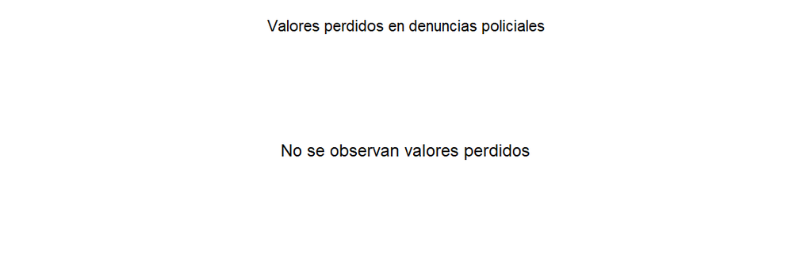

```r
if (sum(faltantes_denuncias$n_faltantes) == 0) {
  ggplot() +
    annotate(
      "text",
      x = 0.5,
      y = 0.5,
      label = "No se observan valores perdidos",
      size = 5
    ) +
    labs(title = "Valores perdidos en denuncias policiales") +
    theme_void(base_size = 11) +
    theme(
      plot.title = element_text(
        size = 13,
        hjust = 0.5,
        margin = margin(b = 10)
      ),
      plot.margin = margin(t = 16, r = 24, b = 16, l = 24)
    )
} else {
  limite_faltantes_denuncias <- max(faltantes_denuncias$pct_faltantes, 0.01)

  faltantes_denuncias |>
    filter(n_faltantes > 0) |>
    mutate(variable = fct_reorder(variable, pct_faltantes)) |>
    ggplot(aes(x = pct_faltantes, y = variable)) +
    geom_col(fill = "#8a817c") +
    scale_x_continuous(
      labels = percent_format(accuracy = 0.1),
      limits = c(0, limite_faltantes_denuncias),
      expand = expansion(mult = c(0, 0.05))
    ) +
    scale_y_discrete(labels = label_wrap(28)) +
    labs(
      title = "Valores perdidos en denuncias policiales",
      x = "% de filas con valor perdido",
      y = NULL
    ) +
    tema_sesion()
}
```

El gráfico resume si hay campos incompletos. Cuando no aparecen faltantes, igualmente conviene mostrarlo: también es un hallazgo de calidad de datos.

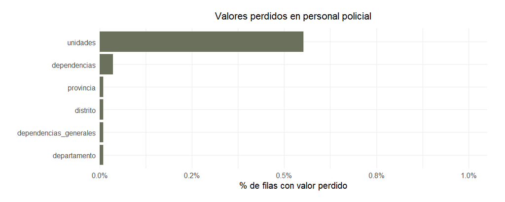

```r
preparar_bases_limpias()

faltantes_personal <- personal_limpia |>
  # Repetimos el diagnóstico para la base de personal policial.
  summarise(across(everything(), ~ sum(is.na(.x)))) |>
  pivot_longer(
    cols = everything(),
    names_to = "variable",
    values_to = "n_faltantes"
  ) |>
  mutate(pct_faltantes = n_faltantes / nrow(personal_limpia)) |>
  arrange(desc(n_faltantes))

if (sum(faltantes_personal$n_faltantes) == 0) {
  ggplot() +
    annotate(
      "text",
      x = 0.5,
      y = 0.5,
      label = "No se observan valores perdidos",
      size = 5
    ) +
    labs(title = "Valores perdidos en personal policial") +
    theme_void(base_size = 11) +
    theme(
      plot.title = element_text(
        size = 13,
        hjust = 0.5,
        margin = margin(b = 10)
      ),
      plot.margin = margin(t = 16, r = 24, b = 16, l = 24)
    )
} else {
  limite_faltantes_personal <- max(faltantes_personal$pct_faltantes, 0.01)

  faltantes_personal |>
    filter(n_faltantes > 0) |>
    mutate(variable = fct_reorder(variable, pct_faltantes)) |>
    ggplot(aes(x = pct_faltantes, y = variable)) +
    geom_col(fill = "#6b705c") +
    scale_x_continuous(
      labels = percent_format(accuracy = 0.1),
      limits = c(0, limite_faltantes_personal),
      expand = expansion(mult = c(0, 0.05))
    ) +
    scale_y_discrete(labels = label_wrap(28)) +
    labs(
      title = "Valores perdidos en personal policial",
      x = "% de filas con valor perdido",
      y = NULL
    ) +
    tema_sesion()
}
```

En personal policial sí aparecen faltantes en algunas variables administrativas. Esto no impide usar la base, pero alerta sobre campos que podrían requerir revisión antes de análisis más finos.

## 6 Duplicados

Un duplicado puede ser una fila totalmente repetida o una repetición según variables clave. Siempre debemos definir qué significa “duplicado” según la base.

### 6.1 Filas totalmente duplicadas

```r
preparar_bases_limpias()

tibble(
  # Comparamos filas totales con filas únicas.
  base = c("denuncias", "personal", "parque", "infraestructura"),
  filas = c(
    nrow(denuncias_limpia),
    nrow(personal_limpia),
    nrow(parque_limpia),
    nrow(infraestructura_limpia)
  ),
  filas_unicas = c(
    nrow(distinct(denuncias_limpia)),
    nrow(distinct(personal_limpia)),
    nrow(distinct(parque_limpia)),
    nrow(distinct(infraestructura_limpia))
  )
) |>
  mutate(duplicados_exactos = filas - filas_unicas)
```

| base | filas | filas_unicas | duplicados_exactos |
| --- | --- | --- | --- |
| denuncias | 355947 | 355947 | 0 |
| personal | 19187 | 19187 | 0 |
| parque | 8232 | 8232 | 0 |
| infraestructura | 1319 | 1319 | 0 |

Comparar filas totales y filas únicas permite detectar duplicados exactos. Si aparecen, el siguiente paso no es borrar automáticamente, sino verificar si el duplicado representa un error o una repetición válida de la fuente.

### 6.2 Duplicados según llaves sustantivas

En denuncias, una llave razonable puede ser año, mes, ubigeo y modalidad.

```r
preparar_bases_limpias()

denuncias_duplicadas_clave <- denuncias_limpia |>
  # count() cuenta repeticiones por la llave que definimos.
  count(anio, mes, ubigeo_hecho, p_modalidades, name = "n") |>
  filter(n > 1) |>
  arrange(desc(n))

denuncias_duplicadas_clave
```

| anio | mes | ubigeo_hecho | p_modalidades | n |
| --- | --- | --- | --- | --- |

Aquí revisamos duplicados con una llave sustantiva. Esta mirada es más útil que buscar filas idénticas, porque pregunta si una misma combinación de año, mes, distrito y modalidad aparece más de una vez.

## 7 Codificación y caracteres extraños

Algunas bases públicas pueden venir con problemas de codificación. Un primer síntoma son caracteres como `�`.

```r
cargar_datos_originales()

trata_utf8 <- read_csv(
  # Primero intentamos leer con UTF-8.
  file.path(ruta_csv, "trata.csv"),
  locale = locale(encoding = "UTF-8"),
  show_col_types = FALSE
)

names(trata_utf8)
```

```
 [1] "A\xd1O"                    "MES"
 [3] "CCDD"                      "lugar"
 [5] "PROVINCIA"                 "DISTRITO"
 [7] "COMISAR\xcdA"              "categor\xeda"
 [9] "Denuncias por comisi\xf3n" "Valor"
```

Si vemos caracteres como `�`, probablemente la base fue guardada con otra codificación. Es una señal de alerta antes de limpiar nombres o analizar categorías de texto.

Si los nombres o valores aparecen con caracteres extraños, podemos probar otra codificación.

```r
trata_latin1 <- read_csv(
  # Si aparecen caracteres extraños, probamos Latin1.
  file.path(ruta_csv, "trata.csv"),
  locale = locale(encoding = "Latin1"),
  show_col_types = FALSE
) |>
  clean_names()

names(trata_latin1)
```

```
 [1] "ano"                    "mes"                    "ccdd"
 [4] "lugar"                  "provincia"              "distrito"
 [7] "comisaria"              "categoria"              "denuncias_por_comision"
[10] "valor"
```

```r
trata_latin1 |>
  select(1:8) |>
  head()
```

| ano | mes | ccdd | lugar | provincia | distrito | comisaria | categoria |
| --- | --- | --- | --- | --- | --- | --- | --- |
| 2017 | 1 | 2 | ÁNCASH | SANTA | CHIMBOTE | DIVICAJ -DEPINTRAP | CAPTACIÓN |
| 2017 | 1 | 2 | ÁNCASH | SANTA | CHIMBOTE | DIVICAJ -DEPINTRAP | CAPTACIÓN |
| 2017 | 1 | 2 | ÁNCASH | SANTA | CHIMBOTE | DIVICAJ -DEPINTRAP | CAPTACIÓN |
| 2017 | 1 | 2 | ÁNCASH | SANTA | CHIMBOTE | DIVICAJ -DEPINTRAP | CAPTACIÓN |
| 2017 | 1 | 2 | ÁNCASH | SANTA | CHIMBOTE | DIVICAJ -DEPINTRAP | CAPTACIÓN |
| 2017 | 1 | 2 | ÁNCASH | SANTA | CHIMBOTE | DIVICAJ -DEPINTRAP | CAPTACIÓN |

Al leer con `Latin1`, los nombres y categorías pueden recuperarse mejor. Este tipo de prueba es importante cuando trabajamos con bases públicas descargadas de distintas plataformas.

## 8 Estandarización de ubigeo

El `ubigeo` debe tratarse como texto, no como número. Si se lee como número, se pueden perder ceros a la izquierda.

```r
preparar_bases_limpias()

tibble(
  # Estos casos muestran por qué el ubigeo debe trabajarse como texto.
  ubigeo_original = c(10101, "150101", "70101.0", NA)
) |>
  mutate(ubigeo_estandar = formatear_ubigeo(ubigeo_original))
```

| ubigeo_original | ubigeo_estandar |
| --- | --- |
| 10101 | 010101 |
| 150101 | 150101 |
| 70101.0 | 070101 |
| NA | NA |

```r
preparar_bases_trabajo()

denuncias_limpia |>
  count(ubigeo, sort = TRUE) |>
  head()
```

| ubigeo | n |
| --- | --- |
| 070101 | 693 |
| 150101 | 689 |
| 150132 | 688 |
| 150135 | 684 |
| 150110 | 679 |
| 150103 | 675 |

El `ubigeo` se transforma a texto para conservar ceros a la izquierda. Esta decisión parece pequeña, pero es central: si el código se trata como número, varias fusiones pueden fallar silenciosamente.

### 8.1 Verificar ubicaciones sin ubigeo

```r
preparar_bases_trabajo()

denuncias_limpia |>
  # Buscamos registros sin ubigeo válido.
  filter(is.na(ubigeo) | ubigeo == "000000") |>
  count(dpto_hecho_new, prov_hecho, dist_hecho, sort = TRUE)
```

| dpto_hecho_new | prov_hecho | dist_hecho | n |
| --- | --- | --- | --- |

Si esta tabla devuelve registros, habría que revisar esos casos antes de fusionar. Un distrito sin ubigeo puede quedar fuera de cruces con parque automotor, comisarías u otras bases territoriales.

## 9 Primeras transformaciones

### 9.1 Total de denuncias por año

```r
preparar_bases_trabajo()

denuncias_anio <- denuncias_limpia |>
  # Agrupamos por año y sumamos el número de denuncias.
  group_by(anio) |>
  summarise(
    denuncias = sum(cantidad, na.rm = TRUE),
    .groups = "drop"
  )

denuncias_anio
```

| anio | denuncias |
| --- | --- |
| 2018 | 775473 |
| 2019 | 855724 |
| 2020 | 648835 |
| 2021 | 754151 |
| 2022 | 876803 |
| 2023 | 1043136 |
| 2024 | 1010920 |
| 2025 | 880714 |
| 2026 | 195342 |

Esta agregación permite observar la serie anual de denuncias. El año 2026 debe interpretarse con cuidado porque la base llega solo hasta marzo, no al año completo.

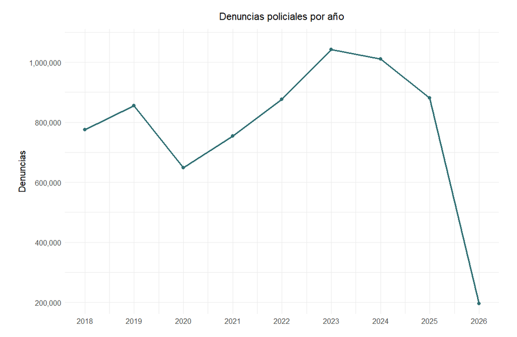

```r
ggplot(denuncias_anio, aes(x = anio, y = denuncias)) +
  geom_line(linewidth = 1, color = "#2f6f73") +
  geom_point(size = 2, color = "#2f6f73") +
  scale_x_continuous(breaks = denuncias_anio$anio) +
  scale_y_continuous(labels = comma, expand = expansion(mult = c(0.04, 0.08))) +
  labs(
    title = "Denuncias policiales por año",
    x = NULL,
    y = "Denuncias"
  ) +
  tema_sesion()
```

La caída de 2026 no debe leerse como reducción anual del delito: responde a que el año está incompleto. Este es un buen ejemplo de por qué siempre se revisa la fecha de corte.

### 9.2 Principales modalidades

```r
preparar_bases_limpias()

modalidades_top <- denuncias_limpia |>
  # Agrupamos por modalidad y conservamos las principales categorías.
  group_by(p_modalidades) |>
  summarise(
    denuncias = sum(cantidad, na.rm = TRUE),
    .groups = "drop"
  ) |>
  slice_max(denuncias, n = 12) |>
  mutate(p_modalidades = fct_reorder(p_modalidades, denuncias))

modalidades_top
```

| p_modalidades | denuncias |
| --- | --- |
| Otros | 2688144 |
| Violencia contra la mujer e integrantes | 1864277 |
| Hurto | 1408214 |
| Robo | 753427 |
| Estafa | 205270 |
| Extorsión | 106729 |
| Homicidio | 15037 |

Las modalidades muestran que no todos los registros tienen el mismo peso analítico. Algunas categorías amplias, como “Otros”, pueden necesitar desagregación o discusión metodológica.

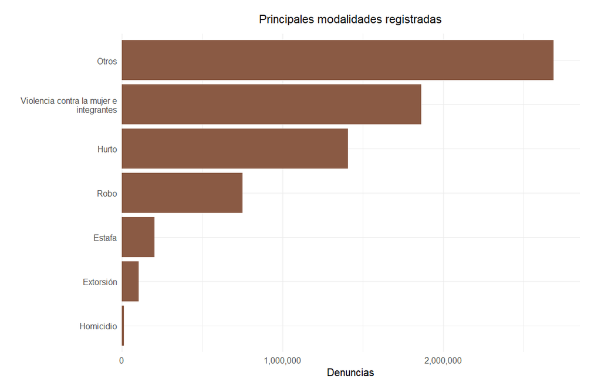

```r
ggplot(modalidades_top, aes(x = denuncias, y = p_modalidades)) +
  geom_col(fill = "#8a5a44") +
  scale_x_continuous(labels = comma, expand = expansion(mult = c(0, 0.06))) +
  scale_y_discrete(labels = label_wrap(32)) +
  labs(
    title = "Principales modalidades registradas",
    x = "Denuncias",
    y = NULL
  ) +
  tema_sesion()
```

El gráfico ayuda a priorizar categorías para análisis posteriores. También muestra cuándo una categoría residual concentra demasiados casos y puede ocultar heterogeneidad.

### 9.3 Personal policial por departamento

```r
preparar_bases_limpias()

personal_departamento <- personal_limpia |>
  # Sumamos efectivos por departamento.
  group_by(departamento) |>
  summarise(
    efectivos = sum(cantidad, na.rm = TRUE),
    .groups = "drop"
  ) |>
  arrange(desc(efectivos))

personal_departamento
```

| departamento | efectivos |
| --- | --- |
| LIMA METROPOLITANA | 52127 |
| CUSCO | 6715 |
| AREQUIPA | 6522 |
| JUNÍN | 6011 |
| PIURA | 5484 |
| LAMBAYEQUE | 5373 |
| LA LIBERTAD | 5309 |
| ÁNCASH | 4778 |
| PROV. CONST. DEL CALLAO | 4528 |
| PUNO | 4430 |

[output cut: 17 more lines]

Esta tabla resume la distribución territorial del personal. Para interpretarla mejor, luego podría cruzarse con población, denuncias o número de comisarías.

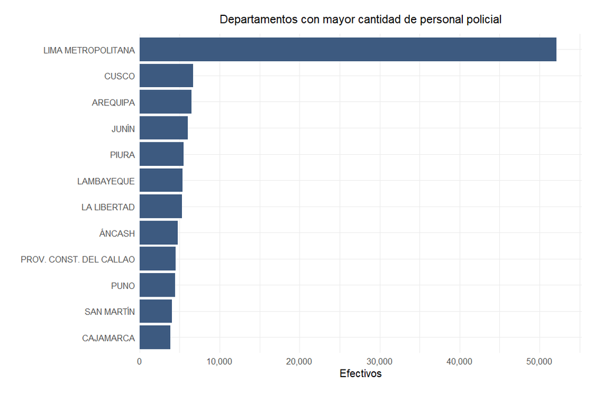

```r
personal_departamento |>
  slice_max(efectivos, n = 12) |>
  mutate(departamento = fct_reorder(departamento, efectivos)) |>
  ggplot(aes(x = efectivos, y = departamento)) +
  geom_col(fill = "#3d5a80") +
  scale_x_continuous(labels = comma, expand = expansion(mult = c(0, 0.06))) +
  scale_y_discrete(labels = label_wrap(24)) +
  labs(
    title = "Departamentos con mayor cantidad de personal policial",
    x = "Efectivos",
    y = NULL
  ) +
  tema_sesion()
```

Lima Metropolitana concentra una parte importante del personal policial. Esto no necesariamente implica mayor cobertura relativa: para eso necesitaríamos tasas o indicadores por población.

### 9.4 Estado del parque automotor

```r
preparar_bases_trabajo()

parque_estado <- parque_limpia |>
  # Sumamos vehículos según su estado operativo.
  group_by(estado) |>
  summarise(
    vehiculos = sum(cantidad, na.rm = TRUE),
    .groups = "drop"
  ) |>
  arrange(desc(vehiculos))

parque_estado
```

| estado | vehiculos |
| --- | --- |
| OPERATIVO | 12219 |
| INOPERATIVO IRRECUPERABLE | 4835 |
| INOPERATIVO RECUPERABLE | 3354 |

El estado del parque automotor permite distinguir recursos disponibles de recursos registrados. Para gestión pública, la diferencia entre operativo e inoperativo es sustantiva.

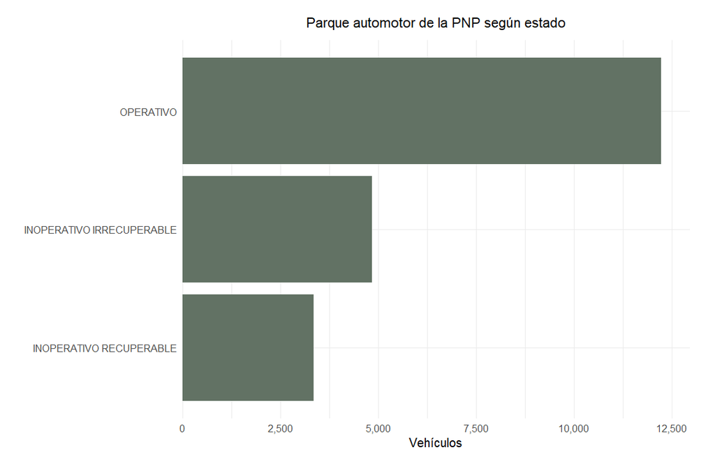

```r
ggplot(parque_estado, aes(x = fct_reorder(estado, vehiculos), y = vehiculos)) +
  geom_col(fill = "#627264") +
  coord_flip() +
  scale_x_discrete(labels = label_wrap(26)) +
  scale_y_continuous(labels = comma, expand = expansion(mult = c(0, 0.06))) +
  labs(
    title = "Parque automotor de la PNP según estado",
    x = NULL,
    y = "Vehículos"
  ) +
  tema_sesion()
```

Esta visualización permite ver rápidamente la composición del parque automotor. Si una proporción alta está inoperativa, el total de vehículos puede sobreestimar la capacidad real.

## 10 Fusionar bases de datos

Para unir bases necesitamos una llave común. En este ejercicio usaremos `ubigeo`.

### 10.1 Preparar denuncias por distrito

```r
preparar_bases_trabajo()

denuncias_distrito <- denuncias_limpia |>
  # Nos quedamos con los años recientes para el ejercicio de fusión.
  filter(anio >= 2024) |>
  group_by(ubigeo, llave_distrito, dpto_hecho_new, prov_hecho, dist_hecho) |>
  summarise(
    denuncias_2024_2026 = sum(cantidad, na.rm = TRUE),
    .groups = "drop"
  )

denuncias_distrito
```

| ubigeo | llave_distrito | dpto_hecho_new | prov_hecho | dist_hecho | denuncias_2024_2026 |
| --- | --- | --- | --- | --- | --- |
| 010101 | AMAZONAS\|CHACHAPOYAS\|CHACHAPOYAS | AMAZONAS | CHACHAPOYAS | CHACHAPOYAS | 3775 |
| 010102 | AMAZONAS\|CHACHAPOYAS\|ASUNCION | AMAZONAS | CHACHAPOYAS | ASUNCION | 14 |
| 010103 | AMAZONAS\|CHACHAPOYAS\|BALSAS | AMAZONAS | CHACHAPOYAS | BALSAS | 74 |
| 010104 | AMAZONAS\|CHACHAPOYAS\|CHETO | AMAZONAS | CHACHAPOYAS | CHETO | 8 |
| 010105 | AMAZONAS\|CHACHAPOYAS\|CHILIQUIN | AMAZONAS | CHACHAPOYAS | CHILIQUIN | 8 |
| 010106 | AMAZONAS\|CHACHAPOYAS\|CHUQUIBAMBA | AMAZONAS | CHACHAPOYAS | CHUQUIBAMBA | 33 |
| 010107 | AMAZONAS\|CHACHAPOYAS\|GRANADA | AMAZONAS | CHACHAPOYAS | GRANADA | 3 |
| 010108 | AMAZONAS\|CHACHAPOYAS\|HUANCAS | AMAZONAS | CHACHAPOYAS | HUANCAS | 13 |
| 010109 | AMAZONAS\|CHACHAPOYAS\|LA JALCA | AMAZONAS | CHACHAPOYAS | LA JALCA | 162 |
| 010110 | AMAZONAS\|CHACHAPOYAS\|LEIMEBAMBA | AMAZONAS | CHACHAPOYAS | LEIMEBAMBA | 110 |

[output cut: 1798 more lines]

Al agregar por distrito pasamos de una base de eventos agregados por modalidad y mes a una base territorial. Esta será la unidad que usaremos para cruzar información con recursos policiales.

### 10.2 Preparar parque automotor por distrito

```r
preparar_bases_trabajo()

parque_distrito <- parque_limpia |>
  # Agregamos vehículos por distrito antes de unir.
  group_by(ubigeo, nombdepto, nombprov, nombdist) |>
  summarise(
    vehiculos_pnp = sum(cantidad, na.rm = TRUE),
    vehiculos_operativos = sum(cantidad[estado == "OPERATIVO"], na.rm = TRUE),
    .groups = "drop"
  )

parque_distrito
```

| ubigeo | nombdepto | nombprov | nombdist | vehiculos_pnp | vehiculos_operativos |
| --- | --- | --- | --- | --- | --- |
| 010101 | AMAZONAS | CHACHAPOYAS | CHACHAPOYAS | 65 | 30 |
| 010201 | AMAZONAS | BAGUA | BAGUA | 10 | 6 |
| 010202 | AMAZONAS | BAGUA | ARAMANGO | 2 | 1 |
| 010203 | AMAZONAS | BAGUA | COPALLIN | 2 | 1 |
| 010205 | AMAZONAS | BAGUA | IMAZA | 1 | 1 |
| 010301 | AMAZONAS | BONGARA | JUMBILLA | 2 | 1 |
| 010306 | AMAZONAS | BONGARA | FLORIDA | 4 | 2 |
| 010307 | AMAZONAS | BONGARA | JAZAN | 12 | 9 |
| 010311 | AMAZONAS | BONGARA | VALERA | 1 | 0 |
| 010401 | AMAZONAS | CONDORCANQUI | NIEVA | 3 | 3 |

[output cut: 1003 more lines]

El parque automotor se resume por distrito para que tenga la misma unidad de análisis que las denuncias. Antes de fusionar, cada base debe estar al mismo nivel de agregación.

### 10.3 Leer ubicación de comisarías 2024

La hoja `CPNP_GEO` tiene información georreferenciada de comisarías. En esta versión, el campo `cod_inei` no corresponde al ubigeo completo de seis dígitos; por eso construiremos una llave textual con departamento, provincia y distrito.

```r
preparar_bases_trabajo()

comisarias_geo <- read_csv(
  # Leemos la base ligera con ubicación de comisarías.
  file.path(ruta_comisarias, "comisarias_geo.csv"),
  show_col_types = FALSE
) |>
  mutate(
    llave_distrito = paste(
      normalizar_texto(departamen),
      normalizar_texto(provincia),
      normalizar_texto(distrito),
      sep = "|"
    )
  )

glimpse(comisarias_geo)
```

```
Rows: 1,326
Columns: 25
$ n              <dbl> 1, 2, 3, 4, 5, 6, 7, 8, 9, 10, 11, 12, 13, 14, 15, 16, …
$ clas_muni      <chr> "A", "A", "B", "G", "G", "B", "D", "D", "D", "A", "B", …
$ cod_inei       <chr> "0944", "0945", "0272", "0928", "1102", "1114", "0601",…
$ cod_cpnp       <chr> "4525", "4532", "1529", "4550", "5908", "5920", "3105",…
$ comisaria      <chr> "CPNP JULIACA", "CPNP SANTA BARBARA", "CPNP SANTA MARIA…
$ tipo_comi      <chr> "A", "B", "A", "E", "C", "B", "B", "B", "C", "B", "D", …
$ cod_uni        <dbl> 219303, 219307, 222078, 219335, 217489, 217493, 217909,…
$ zona_utm       <chr> "UTM / 19 SUR / WGS84", "UTM / 19 SUR / WGS84", "UTM / …
$ categoria      <chr> "PUNO", "PUNO", "AMAZONAS", "PUNO", "HUANUCO", "HUANUCO…
$ resolucion     <chr> "APROBADO CON RESOLUCION DE COMANDANCIA GENERAL DE LA P…
$ id_dpto        <chr> "21", "21", "01", "21", "10", "10", "12", "12", "12", "…
$ departamen     <chr> "PUNO", "PUNO", "AMAZONAS", "PUNO", "HUANUCO", "HUANUCO…
$ id_prov        <chr> "2111", "2111", "0104", "2106", "1001", "1008", "1203",…
$ provincia      <chr> "SAN ROMAN", "SAN ROMAN", "CONDORCANQUI", "HUANCANE", "…
$ id_dist        <chr> "211101", "211101", "010401", "210607", "100103", "1008…
$ distrito       <chr> "JULIACA", "JULIACA", "NIEVA", "TARACO", "CHINCHAO", "P…
$ cod_divpol     <chr> "18R1A", "18R1A", "19R1A", "18R1A", "08R1B", "08R1B", "…
$ divpol_div     <chr> "DIVOPUS JULIACA", "DIVOPUS JULIACA", "DIVOPUS AMAZONAS…
$ cod_macror     <chr> "18", "18", "19", "18", "08", "08", "10", "10", "10", "…
$ macroregpo     <chr> "PUNO", "PUNO", "SAN MARTIN", "PUNO", "HUANUCO", "HUANU…
$ cod_regpol     <chr> "18R1", "18R1", "19R1", "18R1", "08R1", "08R1", "10R2",…
$ regionpol      <chr> "PUNO", "PUNO", "AMAZONAS", "PUNO", "HUANUCO", "HUANUCO…
$ latitud        <dbl> -15.492585, -15.504741, -4.592240, -15.297966, -9.80165…
$ longitud       <dbl> -70.12805, -70.12801, -77.86418, -69.97882, -76.07137, …
$ llave_distrito <chr> "PUNO|SAN ROMAN|JULIACA", "PUNO|SAN ROMAN|JULIACA", "AM…
```

Esta base aporta ubicación de comisarías, pero su código `cod_inei` no es directamente comparable con el `ubigeo`. Por eso usamos una llave textual normalizada como solución práctica para la sesión.

```r
if (!exists("comisarias_geo")) {
  preparar_fusiones()
}

comisarias_distrito <- comisarias_geo |>
  # Contamos comisarías únicas por distrito normalizado.
  group_by(llave_distrito) |>
  summarise(
    comisarias = n_distinct(cod_cpnp),
    .groups = "drop"
  )

comisarias_distrito
```

| llave_distrito | comisarias |
| --- | --- |
| AMAZONAS\|BAGUA\|ARAMANGO | 2 |
| AMAZONAS\|BAGUA\|BAGUA | 1 |
| AMAZONAS\|BAGUA\|COPALLIN | 1 |
| AMAZONAS\|BAGUA\|IMAZA | 2 |
| AMAZONAS\|BAGUA\|LA PECA | 1 |
| AMAZONAS\|BONGARA\|CHURUJA | 1 |
| AMAZONAS\|BONGARA\|FLORIDA | 1 |
| AMAZONAS\|BONGARA\|JAZAN | 1 |
| AMAZONAS\|BONGARA\|JUMBILLA | 1 |
| AMAZONAS\|BONGARA\|VALERA | 1 |

[output cut: 1049 more lines]

Contar comisarías por distrito permite pasar de una base de establecimientos a un indicador territorial comparable con denuncias y vehículos.

### 10.4 Hacer el join

```r
preparar_fusiones()

base_distrital <- denuncias_distrito |>
  # left_join() conserva todos los distritos de denuncias.
  left_join(
    parque_distrito |> select(ubigeo, vehiculos_pnp, vehiculos_operativos),
    by = "ubigeo"
  ) |>
  # Usamos llave textual porque el código INEI de comisarías no es ubigeo completo.
  left_join(comisarias_distrito, by = "llave_distrito") |>
  mutate(
    # Si no hubo cruce, asumimos cero recursos registrados en esta base.
    vehiculos_pnp = replace_na(vehiculos_pnp, 0),
    vehiculos_operativos = replace_na(vehiculos_operativos, 0),
    comisarias = replace_na(comisarias, 0)
  )

base_distrital
```

| ubigeo | llave_distrito | dpto_hecho_new | prov_hecho | dist_hecho | denuncias_2024_2026 | vehiculos_pnp | vehiculos_operativos | comisarias |
| --- | --- | --- | --- | --- | --- | --- | --- | --- |
| 010101 | AMAZONAS\|CHACHAPOYAS\|CHACHAPOYAS | AMAZONAS | CHACHAPOYAS | CHACHAPOYAS | 3775 | 65 | 30 | 1 |
| 010102 | AMAZONAS\|CHACHAPOYAS\|ASUNCION | AMAZONAS | CHACHAPOYAS | ASUNCION | 14 | 0 | 0 | 0 |
| 010103 | AMAZONAS\|CHACHAPOYAS\|BALSAS | AMAZONAS | CHACHAPOYAS | BALSAS | 74 | 0 | 0 | 1 |
| 010104 | AMAZONAS\|CHACHAPOYAS\|CHETO | AMAZONAS | CHACHAPOYAS | CHETO | 8 | 0 | 0 | 0 |
| 010105 | AMAZONAS\|CHACHAPOYAS\|CHILIQUIN | AMAZONAS | CHACHAPOYAS | CHILIQUIN | 8 | 0 | 0 | 0 |
| 010106 | AMAZONAS\|CHACHAPOYAS\|CHUQUIBAMBA | AMAZONAS | CHACHAPOYAS | CHUQUIBAMBA | 33 | 0 | 0 | 1 |
| 010107 | AMAZONAS\|CHACHAPOYAS\|GRANADA | AMAZONAS | CHACHAPOYAS | GRANADA | 3 | 0 | 0 | 1 |
| 010108 | AMAZONAS\|CHACHAPOYAS\|HUANCAS | AMAZONAS | CHACHAPOYAS | HUANCAS | 13 | 0 | 0 | 0 |
| 010109 | AMAZONAS\|CHACHAPOYAS\|LA JALCA | AMAZONAS | CHACHAPOYAS | LA JALCA | 162 | 0 | 0 | 1 |
| 010110 | AMAZONAS\|CHACHAPOYAS\|LEIMEBAMBA | AMAZONAS | CHACHAPOYAS | LEIMEBAMBA | 110 | 0 | 0 | 1 |

[output cut: 1798 more lines]

La base integrada conserva todos los distritos con denuncias recientes y agrega, cuando existe cruce, información de vehículos y comisarías. Los ceros deben interpretarse como “sin registro cruzado en estas bases”, no necesariamente como ausencia real.

### 10.5 Revisar el resultado del join

```r
if (!exists("base_distrital")) {
  preparar_fusiones()
}

base_distrital |>
  summarise(
    distritos = n(),
    distritos_con_vehiculos = sum(vehiculos_pnp > 0),
    distritos_con_comisarias = sum(comisarias > 0),
    denuncias_total = sum(denuncias_2024_2026, na.rm = TRUE)
  )
```

| distritos | distritos_con_vehiculos | distritos_con_comisarias | denuncias_total |
| --- | --- | --- | --- |
| 1808 | 1009 | 960 | 2086976 |

Este resumen muestra la cobertura del cruce: cuántos distritos tienen información complementaria de vehículos o comisarías y cuántas denuncias acumula la base final.

```r
if (!exists("base_distrital")) {
  preparar_fusiones()
}

base_distrital |>
  arrange(desc(denuncias_2024_2026)) |>
  select(
    dpto_hecho_new,
    prov_hecho,
    dist_hecho,
    denuncias_2024_2026,
    vehiculos_pnp,
    comisarias
  ) |>
  head(20)
```

| dpto_hecho_new | prov_hecho | dist_hecho | denuncias_2024_2026 | vehiculos_pnp | comisarias |
| --- | --- | --- | --- | --- | --- |
| LIMA METROPOLITANA | LIMA | LIMA | 74349 | 2692 | 10 |
| LIMA METROPOLITANA | LIMA | SAN JUAN DE LURIGANCHO | 73859 | 225 | 9 |
| LAMBAYEQUE | CHICLAYO | CHICLAYO | 56532 | 383 | 4 |
| PROV. CONST. DEL CALLAO | CALLAO | CALLAO | 48771 | 547 | 11 |
| LIMA METROPOLITANA | LIMA | COMAS | 42326 | 114 | 5 |
| LA LIBERTAD | TRUJILLO | TRUJILLO | 42233 | 370 | 3 |
| LIMA METROPOLITANA | LIMA | SAN MARTIN DE PORRES | 38728 | 88 | 3 |
| LIMA METROPOLITANA | LIMA | ATE | 37817 | 272 | 4 |
| LIMA METROPOLITANA | LIMA | VILLA MARIA DEL TRIUNFO | 33031 | 114 | 6 |
| LIMA METROPOLITANA | LIMA | LOS OLIVOS | 31903 | 142 | 3 |

[output cut: 10 more lines]

Revisar los distritos con más denuncias permite detectar casos influyentes y decidir si conviene analizarlos por separado, especialmente cuando hay grandes ciudades o distritos capitales.

### 10.6 Visualizar relación entre denuncias y recursos

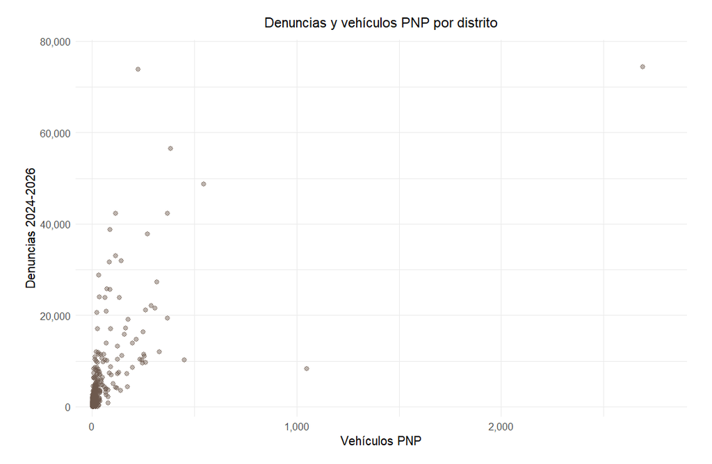

```r
if (!exists("base_distrital")) {
  preparar_fusiones()
}

base_distrital |>
  filter(vehiculos_pnp > 0) |>
  ggplot(aes(x = vehiculos_pnp, y = denuncias_2024_2026)) +
  geom_point(alpha = 0.45, color = "#6c584c", size = 2) +
  scale_x_continuous(labels = comma, expand = expansion(mult = c(0.03, 0.08))) +
  scale_y_continuous(labels = comma, expand = expansion(mult = c(0.03, 0.08))) +
  labs(
    title = "Denuncias y vehículos PNP por distrito",
    x = "Vehículos PNP",
    y = "Denuncias 2024-2026"
  ) +
  tema_sesion()
```

La relación entre denuncias y vehículos no debe interpretarse causalmente. En esta etapa solo exploramos si hay patrones, concentraciones o valores extremos que merezcan revisión.

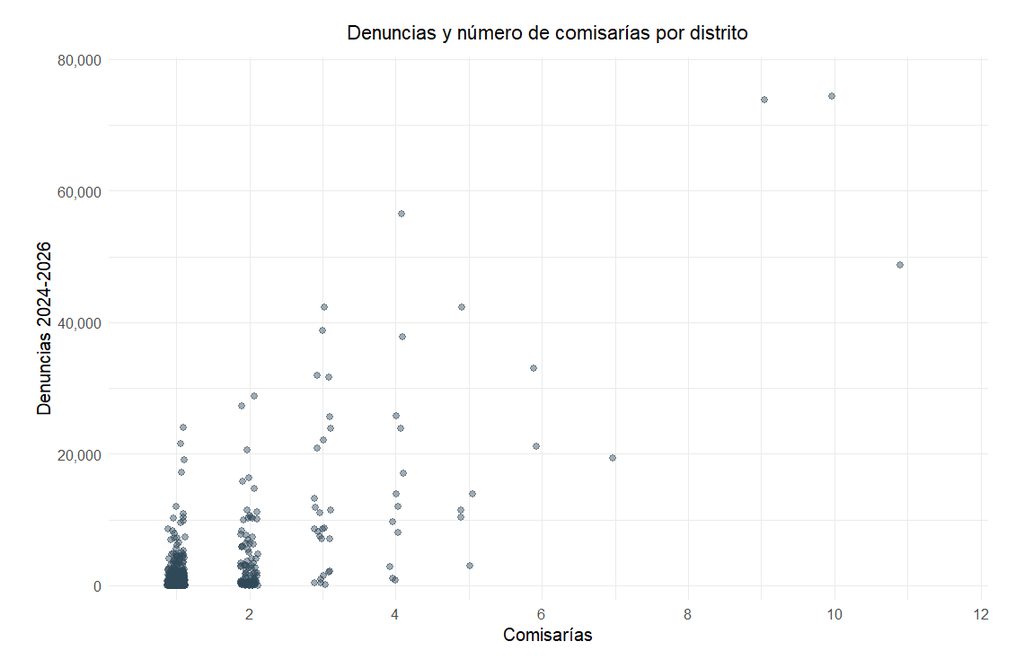

```r
if (!exists("base_distrital")) {
  preparar_fusiones()
}

base_distrital |>
  filter(comisarias > 0) |>
  ggplot(aes(x = comisarias, y = denuncias_2024_2026)) +
  geom_jitter(
    width = 0.12,
    height = 0,
    alpha = 0.45,
    color = "#2f4858",
    size = 2
  ) +
  scale_x_continuous(
    breaks = pretty_breaks(),
    expand = expansion(mult = c(0.08, 0.12))
  ) +
  scale_y_continuous(labels = comma, expand = expansion(mult = c(0.03, 0.08))) +
  labs(
    title = "Denuncias y número de comisarías por distrito",
    x = "Comisarías",
    y = "Denuncias 2024-2026"
  ) +
  tema_sesion()
```

Los distritos con más comisarías tienden a ser territorios urbanos o con mayor actividad policial registrada. Esta relación requiere contexto territorial antes de extraer conclusiones.

## 11 Documentar y validar la base

Antes de exportar una base limpia conviene dejar evidencia de cuatro cosas: de dónde vienen los datos, qué reglas de calidad aplicamos, qué tan bien cruzaron las bases y si necesitamos cambiar la forma de la tabla para analizarla mejor.

### 11.1 Diccionario mínimo de datos

Un diccionario no tiene que ser largo para ser útil. En una primera versión basta con identificar la fuente, la unidad de análisis y el papel de cada variable.

```r
if (!exists("base_distrital")) {
  preparar_fusiones()
}

diccionario_base_distrital <- tibble(
  # Documentamos variables, tipos y significado.
  variable = names(base_distrital),
  tipo = map_chr(base_distrital, ~ class(.x)[1]),
  descripcion = case_when(
    variable == "ubigeo" ~ "Código de seis dígitos del distrito.",
    variable ==
      "llave_distrito" ~ "Llave textual normalizada: departamento, provincia y distrito.",
    variable ==
      "dpto_hecho_new" ~ "Departamento donde ocurrió el hecho registrado.",
    variable == "prov_hecho" ~ "Provincia donde ocurrió el hecho registrado.",
    variable == "dist_hecho" ~ "Distrito donde ocurrió el hecho registrado.",
    variable ==
      "denuncias_2024_2026" ~ "Total de denuncias policiales entre 2024 y marzo de 2026.",
    variable ==
      "vehiculos_pnp" ~ "Total de vehículos PNP registrados en el distrito.",
    variable ==
      "vehiculos_operativos" ~ "Total de vehículos PNP operativos en el distrito.",
    variable ==
      "comisarias" ~ "Número de comisarías identificadas en el distrito.",
    TRUE ~ "Variable auxiliar o proveniente de la fuente original."
  )
)

diccionario_base_distrital
```

| variable | tipo | descripcion |
| --- | --- | --- |
| ubigeo | character | Código de seis dígitos del distrito. |
| llave_distrito | character | Llave textual normalizada: departamento, provincia y distrito. |
| dpto_hecho_new | character | Departamento donde ocurrió el hecho registrado. |
| prov_hecho | character | Provincia donde ocurrió el hecho registrado. |
| dist_hecho | character | Distrito donde ocurrió el hecho registrado. |
| denuncias_2024_2026 | numeric | Total de denuncias policiales entre 2024 y marzo de 2026. |
| vehiculos_pnp | numeric | Total de vehículos PNP registrados en el distrito. |
| vehiculos_operativos | numeric | Total de vehículos PNP operativos en el distrito. |
| comisarias | integer | Número de comisarías identificadas en el distrito. |

El diccionario hace explícito qué significa cada variable. Esto es especialmente importante cuando una base será compartida o reutilizada en otra sesión.

También es útil registrar una ficha breve de trazabilidad de las bases utilizadas.

```r
trazabilidad <- tibble(
  # Esta ficha permite recordar fuente, unidad y uso de cada archivo.
  base = c(
    "Denuncias policiales",
    "Parque automotor PNP",
    "Comisarías georreferenciadas"
  ),
  archivo = c(
    "denuncias.csv",
    "parque.csv",
    "Información policial_BDs_seguridad_24.xlsx"
  ),
  unidad_original = c(
    "Año, mes, distrito y modalidad",
    "Distrito, tipo de vehículo, estado y procedencia",
    "Comisaría"
  ),
  uso_en_la_sesion = c(
    "Construir denuncias acumuladas por distrito",
    "Agregar vehículos por distrito",
    "Contar comisarías por distrito"
  )
)

trazabilidad
```

| base | archivo | unidad_original | uso_en_la_sesion |
| --- | --- | --- | --- |
| Denuncias policiales | denuncias.csv | Año, mes, distrito y modalidad | Construir denuncias acumuladas por distrito |
| Parque automotor PNP | parque.csv | Distrito, tipo de vehículo, estado y procedencia | Agregar vehículos por distrito |
| Comisarías georreferenciadas | Información policial_BDs_seguridad_24.xlsx | Comisaría | Contar comisarías por distrito |

La trazabilidad permite reconstruir de dónde salió cada indicador. En análisis aplicado, esto ayuda a evitar confundir fuentes, fechas de corte o unidades de análisis.

### 11.2 Reglas de calidad

Las reglas de calidad son pruebas simples que nos avisan si algo no cuadra. No reemplazan el criterio sustantivo, pero ayudan a detectar errores temprano.

```r
if (!exists("base_distrital")) {
  preparar_fusiones()
}

validaciones <- tibble(
  # Cada regla cuenta cuántos registros incumplen una condición básica.
  regla = c(
    "El ubigeo debe tener seis dígitos",
    "Las denuncias no pueden ser negativas",
    "Los vehículos no pueden ser negativos",
    "Los vehículos operativos no pueden superar el total de vehículos",
    "El número de comisarías no puede ser negativo"
  ),
  registros_con_problema = c(
    sum(!str_detect(base_distrital$ubigeo, "^\\d{6}$"), na.rm = TRUE),
    sum(base_distrital$denuncias_2024_2026 < 0, na.rm = TRUE),
    sum(base_distrital$vehiculos_pnp < 0, na.rm = TRUE),
    sum(
      base_distrital$vehiculos_operativos > base_distrital$vehiculos_pnp,
      na.rm = TRUE
    ),
    sum(base_distrital$comisarias < 0, na.rm = TRUE)
  )
)

validaciones
```

| regla | registros_con_problema |
| --- | --- |
| El ubigeo debe tener seis dígitos | 0 |
| Las denuncias no pueden ser negativas | 0 |
| Los vehículos no pueden ser negativos | 0 |
| Los vehículos operativos no pueden superar el total de vehículos | 0 |
| El número de comisarías no puede ser negativo | 0 |

Si una regla devuelve cero problemas, no significa que la base sea perfecta, pero sí que pasó controles básicos de consistencia. Si devuelve casos, esos registros deben revisarse antes de exportar.

```r
if (!exists("base_distrital")) {
  preparar_fusiones()
}

base_distrital |>
  filter(
    !str_detect(ubigeo, "^\\d{6}$") |
      denuncias_2024_2026 < 0 |
      vehiculos_pnp < 0 |
      vehiculos_operativos > vehiculos_pnp |
      comisarias < 0
  )
```

| ubigeo | llave_distrito | dpto_hecho_new | prov_hecho | dist_hecho | denuncias_2024_2026 | vehiculos_pnp | vehiculos_operativos | comisarias |
| --- | --- | --- | --- | --- | --- | --- | --- | --- |

Esta tabla lista los registros que incumplen alguna regla de calidad. Si queda vacía, las reglas definidas no encontraron problemas.

### 11.3 Diagnóstico de fusiones

No basta con hacer un `left_join()`. También debemos revisar qué registros cruzaron y cuáles quedaron fuera.

```r
if (!exists("base_distrital")) {
  preparar_fusiones()
}

parque_sin_denuncias <- parque_distrito |>
  # anti_join() devuelve registros del primer objeto que no cruzan con el segundo.
  anti_join(denuncias_distrito, by = "ubigeo")

denuncias_sin_parque <- denuncias_distrito |>
  anti_join(parque_distrito, by = "ubigeo")

comisarias_sin_denuncias <- comisarias_distrito |>
  anti_join(denuncias_distrito, by = "llave_distrito")

diagnostico_fusiones <- tibble(
  revision = c(
    "Distritos en parque automotor sin denuncias",
    "Distritos en denuncias sin parque automotor",
    "Distritos con comisarías sin denuncias"
  ),
  registros = c(
    nrow(parque_sin_denuncias),
    nrow(denuncias_sin_parque),
    nrow(comisarias_sin_denuncias)
  )
)

diagnostico_fusiones
```

| revision | registros |
| --- | --- |
| Distritos en parque automotor sin denuncias | 4 |
| Distritos en denuncias sin parque automotor | 799 |
| Distritos con comisarías sin denuncias | 99 |

El diagnóstico de fusiones muestra dónde se pierde correspondencia entre bases. Esta revisión es tan importante como el `left_join()`, porque revela límites del cruce.

```r
denuncias_sin_parque |>
  arrange(desc(denuncias_2024_2026)) |>
  select(dpto_hecho_new, prov_hecho, dist_hecho, denuncias_2024_2026) |>
  head(15)
```

| dpto_hecho_new | prov_hecho | dist_hecho | denuncias_2024_2026 |
| --- | --- | --- | --- |
| UCAYALI | CORONEL PORTILLO | MANANTAY | 4276 |
| REGION LIMA | HUAROCHIRI | SAN ANTONIO | 3026 |
| AYACUCHO | HUAMANGA | SAN JUAN BAUTISTA | 2230 |
| REGION LIMA | HUAURA | SANTA MARIA | 1714 |
| PUNO | SAN ROMAN | SAN MIGUEL | 1515 |
| JUNIN | HUANCAYO | PILCOMAYO | 1395 |
| AYACUCHO | HUAMANGA | ANDRES AVELINO CACERES | 1076 |
| APURIMAC | ABANCAY | TAMBURCO | 929 |
| LAMBAYEQUE | FERREÑAFE | PUEBLO NUEVO | 820 |
| PROV. CONST. DEL CALLAO | CALLAO | MI PERU | 798 |

[output cut: 5 more lines]

Estos son distritos con denuncias, pero sin parque automotor cruzado por `ubigeo`. Puede deberse a ausencia real de registro o a diferencias en la codificación territorial.

### 11.4 Reestructurar datos: largo y ancho

Muchas bases se analizan mejor en formato largo: una fila por unidad y por indicador. Para reportes, a veces conviene volver a formato ancho.

```r
if (!exists("base_distrital")) {
  preparar_fusiones()
}

base_indicadores_larga <- base_distrital |>
  # El formato largo facilita comparar varios indicadores con una misma estructura.
  select(
    ubigeo,
    dpto_hecho_new,
    prov_hecho,
    dist_hecho,
    denuncias_2024_2026,
    vehiculos_pnp,
    vehiculos_operativos,
    comisarias
  ) |>
  pivot_longer(
    cols = c(
      denuncias_2024_2026,
      vehiculos_pnp,
      vehiculos_operativos,
      comisarias
    ),
    names_to = "indicador",
    values_to = "valor"
  )

base_indicadores_larga
```

| ubigeo | dpto_hecho_new | prov_hecho | dist_hecho | indicador | valor |
| --- | --- | --- | --- | --- | --- |
| 010101 | AMAZONAS | CHACHAPOYAS | CHACHAPOYAS | denuncias_2024_2026 | 3775 |
| 010101 | AMAZONAS | CHACHAPOYAS | CHACHAPOYAS | vehiculos_pnp | 65 |
| 010101 | AMAZONAS | CHACHAPOYAS | CHACHAPOYAS | vehiculos_operativos | 30 |
| 010101 | AMAZONAS | CHACHAPOYAS | CHACHAPOYAS | comisarias | 1 |
| 010102 | AMAZONAS | CHACHAPOYAS | ASUNCION | denuncias_2024_2026 | 14 |
| 010102 | AMAZONAS | CHACHAPOYAS | ASUNCION | vehiculos_pnp | 0 |
| 010102 | AMAZONAS | CHACHAPOYAS | ASUNCION | vehiculos_operativos | 0 |
| 010102 | AMAZONAS | CHACHAPOYAS | ASUNCION | comisarias | 0 |
| 010103 | AMAZONAS | CHACHAPOYAS | BALSAS | denuncias_2024_2026 | 74 |
| 010103 | AMAZONAS | CHACHAPOYAS | BALSAS | vehiculos_pnp | 0 |

[output cut: 7222 more lines]

El formato largo es útil para comparar indicadores en un mismo campo (`indicador`) y facilita gráficos o resúmenes automatizados.

```r
base_indicadores_larga |>
  group_by(indicador) |>
  summarise(
    minimo = min(valor, na.rm = TRUE),
    mediana = median(valor, na.rm = TRUE),
    promedio = mean(valor, na.rm = TRUE),
    maximo = max(valor, na.rm = TRUE),
    .groups = "drop"
  )
```

| indicador | minimo | mediana | promedio | maximo |
| --- | --- | --- | --- | --- |
| comisarias | 0 | 1 | 0.6725664 | 11 |
| denuncias_2024_2026 | 1 | 77 | 1154.3008850 | 74349 |
| vehiculos_operativos | 0 | 1 | 6.7544248 | 1726 |
| vehiculos_pnp | 0 | 1 | 11.2831858 | 2692 |

Este resumen permite detectar escalas muy distintas entre indicadores. Por ejemplo, denuncias, vehículos y comisarías no tienen magnitudes comparables sin estandarización.

```r
base_indicadores_ancha <- base_indicadores_larga |>
  # Volvemos al formato ancho cuando queremos una columna por indicador.
  pivot_wider(
    names_from = indicador,
    values_from = valor
  )

base_indicadores_ancha
```

| ubigeo | dpto_hecho_new | prov_hecho | dist_hecho | denuncias_2024_2026 | vehiculos_pnp | vehiculos_operativos | comisarias |
| --- | --- | --- | --- | --- | --- | --- | --- |
| 010101 | AMAZONAS | CHACHAPOYAS | CHACHAPOYAS | 3775 | 65 | 30 | 1 |
| 010102 | AMAZONAS | CHACHAPOYAS | ASUNCION | 14 | 0 | 0 | 0 |
| 010103 | AMAZONAS | CHACHAPOYAS | BALSAS | 74 | 0 | 0 | 1 |
| 010104 | AMAZONAS | CHACHAPOYAS | CHETO | 8 | 0 | 0 | 0 |
| 010105 | AMAZONAS | CHACHAPOYAS | CHILIQUIN | 8 | 0 | 0 | 0 |
| 010106 | AMAZONAS | CHACHAPOYAS | CHUQUIBAMBA | 33 | 0 | 0 | 1 |
| 010107 | AMAZONAS | CHACHAPOYAS | GRANADA | 3 | 0 | 0 | 1 |
| 010108 | AMAZONAS | CHACHAPOYAS | HUANCAS | 13 | 0 | 0 | 0 |
| 010109 | AMAZONAS | CHACHAPOYAS | LA JALCA | 162 | 0 | 0 | 1 |
| 010110 | AMAZONAS | CHACHAPOYAS | LEIMEBAMBA | 110 | 0 | 0 | 1 |

[output cut: 1798 more lines]

El formato ancho es más cómodo para revisar una base final por distrito, mientras que el formato largo suele ser mejor para visualización y modelamiento.

## 12 Exportar una base limpia

Guardamos en esta misma carpeta la base distrital construida, su diccionario mínimo y la tabla en formato largo.

```r
if (!exists("base_distrital")) {
  preparar_fusiones()
}

if (!exists("diccionario_base_distrital")) {
  diccionario_base_distrital <- tibble(
    variable = names(base_distrital),
    tipo = map_chr(base_distrital, ~ class(.x)[1]),
    descripcion = "Variable de la base distrital integrada."
  )
}

if (!exists("base_indicadores_larga")) {
  base_indicadores_larga <- base_distrital |>
    select(
      ubigeo,
      dpto_hecho_new,
      prov_hecho,
      dist_hecho,
      denuncias_2024_2026,
      vehiculos_pnp,
      vehiculos_operativos,
      comisarias
    ) |>
    pivot_longer(
      cols = c(
        denuncias_2024_2026,
        vehiculos_pnp,
        vehiculos_operativos,
        comisarias
      ),
      names_to = "indicador",
      values_to = "valor"
    )
}

write_csv(
  # Exportamos la base integrada principal.
  base_distrital,
  file.path(ruta_resultados, "base_sesion2.csv")
)

write_csv(
  # Exportamos el diccionario para documentar la base.
  diccionario_base_distrital,
  file.path(ruta_resultados, "diccionario_sesion2.csv")
)

write_csv(
  # Exportamos una versión en formato largo para ejercicios posteriores.
  base_indicadores_larga,
  file.path(ruta_resultados, "indicadores_sesion2.csv")
)
```

La exportación deja productos reutilizables: la base integrada, un diccionario mínimo y una versión larga para ejercicios posteriores.

## 13 Ejercicios para seguir practicando

1. Usemos `plotly` para explorar interactivamente la relación entre denuncias y comisarías por distrito.
2. Identificar la modalidad más frecuente en cada departamento.
3. Calcular el porcentaje de vehículos operativos por distrito.
4. Encontrar distritos con denuncias policiales, pero sin vehículos PNP registrados.
5. Revisar si hay distritos con `ubigeo` presente en parque automotor, pero no en denuncias.
6. Repetir el join usando solo Lima Metropolitana.
7. Crear una tabla de denuncias por modalidad y año.
8. Exportar una base resumida por departamento.

Estos ejercicios pueden apoyarse en el Posit Assistant de RStudio para revisar errores, pedir explicaciones de código y explorar alternativas de limpieza o visualización.

### 13.1 Ejercicio 1: Gráfico interactivo con plotly

Usamos `plotly` para crear un gráfico interactivo que muestre la relación entre denuncias y comisarías por distrito. Este tipo de gráfico permite explorar los datos de manera dinámica, mostrando información detallada al pasar el cursor sobre cada punto.

Sin embargo, no será visible en el PDF generado, ya que `plotly` está diseñado para entornos HTML. Para verlo, es necesario ejecutar el bloque de código en RStudio, Positron o renderizar el documento en formato HTML.

```r
library(plotly)
if (!exists("base_distrital")) {
  preparar_fusiones()
}

grafico_comisarias <- base_distrital |>
  filter(comisarias > 0) |>
  ggplot(
    aes(
      x = comisarias,
      y = denuncias_2024_2026,
      text = paste0(
        "<b>Distrito:</b> ",
        dist_hecho,
        "<br><b>Departamento:</b> ",
        dpto_hecho_new,
        "<br><b>Comisarías:</b> ",
        comisarias,
        "<br><b>Denuncias:</b> ",
        scales::comma(denuncias_2024_2026)
      )
    )
  ) +
  geom_jitter(
    width = 0.12,
    height = 0,
    alpha = 0.45,
    color = "#2f4858",
    size = 2
  ) +
  scale_x_continuous(
    breaks = pretty_breaks(),
    expand = expansion(mult = c(0.08, 0.12))
  ) +
  scale_y_continuous(
    labels = comma,
    expand = expansion(mult = c(0.03, 0.08))
  ) +
  labs(
    title = "Denuncias y número de comisarías por distrito",
    x = "Comisarías",
    y = "Denuncias 2024-2026"
  ) +
  tema_sesion()

ggplotly(
  grafico_comisarias,
  tooltip = "text"
)
```

[interactive chart not shown]